# Build Probabilistic Machine Learning Apps Using Streamlit

## with PyMC3

## [@emaasit](https://twitter.com/emaasit) • [Bayesian Data Science DC Meetup](https://www.meetup.com/Bayesian-Data-Science-DC/events/270623940) • Washington, D.C. • 05/27/2020

## Materials

**Download slides & code from Github: bit.ly/intro-pml-streamlit**

## Objective

- Target audience: Data Scientists, Analysts, ... Basically anyone who works with data
- Put your analyses in the hands of end users quickly

## Machine Learning: A Probabilistic Perspective

- Probabilistic ML:
  - An Interdisciplinary field that develops both the mathematical foundations and practical applications of systems that learn models of data. (*Ghahramani, 2018*)

[figure not shown]

## Probabilistic Models

- A Model:
  - A model describes data that one could observe from a system (*Ghahramani, 2014*)

[figure not shown]

- Use the mathematics of probability theory to express all forms of uncertainty

[figure not shown]

$$P(\theta \mid y) = \frac{P(y \mid \theta) \, P(\theta)}{P(y)}$$

Where: $\mathbf{\theta}$ = parameters e.g. reproductive metric of an epidemic

- $p(\mathbf{\theta} \mid \textbf{y})$ = posterior over the parameters, given observed data
- $p(\mathbf{\theta})$ = prior over the parameters
- $p(\textbf{y} \mid \mathbf{\theta})$ = likelihood given the covariates & parameters
- $p(\textbf{y})$ = data distribution to ensure normalization

## Case Study: Modeling the COVID-19 Reproduction Metric ,$R_t$, using Gaussian Processes

$R_t$ = the effective reproduction number in an epidemic.

- a measure of the number of people who become infected per infectious person at time $t$.

**Reference**: [Bettencourt, L. M., & Ribeiro, R. M. (2008). Real time bayesian estimation of the epidemic potential of emerging infectious diseases. PLoS One, 3(5)](https://journals.plos.org/plosone/article?id=10.1371/journal.pone.0002185).

## Step 1: Prepare the data

- Reference: Kevin Systrom (2020). The Metric We Need to Manage COVID-19 Rt: the effective reproduction number. http://systrom.com/blog/the-metric-we-need-to-manage-covid-19/
  - **HISTORIC STATE DAILY** data from **https://covidtracking.com/api/v1/states/daily.csv**
  - **ONSET** & **DELAY** data from **Institute for Health Metrics and Evaluation, University of Washington** https://github.com/beoutbreakprepared/nCoV2019

```python
# Historic state daily data
states = pd.read_csv('data/states.csv',
                     parse_dates=['date'],
                     index_col=['state', 'date']).sort_index()
```

```python
state = "CA"
states.xs(state).head(n=6)
```

| date | positive | negative | pending | hospitalizedCurrently | hospitalizedCumulative | inIcuCurrently | inIcuCumulative | onVentilatorCurrently | onVentilatorCumulative | recovered | ... | hospitalized | total | totalTestResults | posNeg | fips | deathIncrease | hospitalizedIncrease | negativeIncrease | positiveIncrease | totalTestResultsIncrease |
| --- | --- | --- | --- | --- | --- | --- | --- | --- | --- | --- | --- | --- | --- | --- | --- | --- | --- | --- | --- | --- | --- |
| 2020-03-04 | 53.0 | 462.0 | NaN | NaN | NaN | NaN | NaN | NaN | NaN | NaN | ... | NaN | 515 | 515 | 515 | 6 | NaN | NaN | NaN | NaN | NaN |
| 2020-03-05 | 53.0 | 462.0 | NaN | NaN | NaN | NaN | NaN | NaN | NaN | NaN | ... | NaN | 515 | 515 | 515 | 6 | 0.0 | 0.0 | 0.0 | 0.0 | 0.0 |
| 2020-03-06 | 60.0 | 462.0 | NaN | NaN | NaN | NaN | NaN | NaN | NaN | NaN | ... | NaN | 522 | 522 | 522 | 6 | 0.0 | 0.0 | 0.0 | 7.0 | 7.0 |
| 2020-03-07 | 69.0 | 462.0 | NaN | NaN | NaN | NaN | NaN | NaN | NaN | NaN | ... | NaN | 531 | 531 | 531 | 6 | 0.0 | 0.0 | 0.0 | 9.0 | 9.0 |
| 2020-03-08 | 88.0 | 462.0 | NaN | NaN | NaN | NaN | NaN | NaN | NaN | NaN | ... | NaN | 550 | 550 | 550 | 6 | 0.0 | 0.0 | 0.0 | 19.0 | 19.0 |
| 2020-03-09 | 114.0 | 690.0 | NaN | NaN | NaN | NaN | NaN | NaN | NaN | NaN | ... | NaN | 804 | 804 | 804 | 6 | 0.0 | 0.0 | 228.0 | 26.0 | 254.0 |

6 rows × 25 columns

```python
confirmed = states.xs(state).positive.diff().dropna()
confirmed.head(n=5)
```

```
date
2020-03-05     0.0
2020-03-06     7.0
2020-03-07     9.0
2020-03-08    19.0
2020-03-09    26.0
Name: positive, dtype: float64
```

```python
onset = pd.read_csv('data/onset.csv', parse_dates=['date'])
onset.tail(n=6)
```

|  | Unnamed: 0 | date | onset |
| --- | --- | --- | --- |
| 141 | 141 | 2020-05-20 | 694.333899 |
| 142 | 142 | 2020-05-21 | 511.864452 |
| 143 | 143 | 2020-05-22 | 355.491271 |
| 144 | 144 | 2020-05-23 | 208.181377 |
| 145 | 145 | 2020-05-24 | 91.134093 |
| 146 | 146 | 2020-05-25 | 12.098933 |

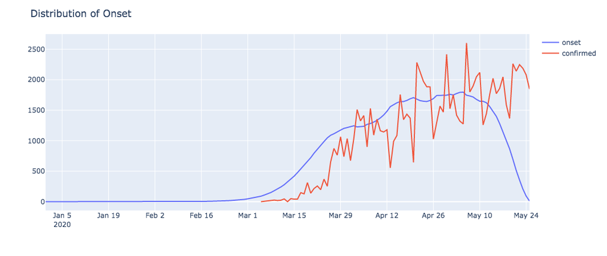

```python
fig1
```

```python
cumulative_p_delay = pd.read_csv('data/cumulative_p_delay.csv')
cumulative_p_delay.head(n=6)
```

|  | Unnamed: 0 | cumulative_p_delay |
| --- | --- | --- |
| 0 | 0 | 1.0 |
| 1 | 1 | 1.0 |
| 2 | 2 | 1.0 |
| 3 | 3 | 1.0 |
| 4 | 4 | 1.0 |
| 5 | 5 | 1.0 |

```python
X_shape = len(onset) - 1

# The inputs to the GP, they must be arranged as a column vector
X = np.arange(X_shape)[:, None]
X.shape
```

```
(146, 1)
```

```python
# The observed data
y = onset.onset.round().values[1:]
y.shape
```

```
(146,)
```

## Step 2: Instantiate a model

- We have data for the number of new cases (count) on the previous day.
- Choose an appropriate likelihood function function that says how likely we are to see $k$ new cases, given a value of $R_t$.
- Let's choose a Poisson parameterized by fixing $k$ and varying $R_t$.

$$P\left(k|R_t\right) = \frac{\lambda^k e^{-\lambda}}{k!}$$

- Where the expecation of $\lambda$ of the poisson is the positive, non-zero, expected onset cases we think we'd see today.:

$$ \lambda = k_{t-1}e^{\gamma(R_t-1)}$$

- If we define $\theta = \gamma(R_t-1)$, we can recover $R_t$ easily by $R_t = \frac{\theta}{\gamma}+1$

**Reference**: [Bettencourt, L. M., & Ribeiro, R. M. (2008). Real time bayesian estimation of the epidemic potential of emerging infectious diseases. PLoS One, 3(5)](https://journals.plos.org/plosone/article?id=10.1371/journal.pone.0002185).

```python
with pm.Model() as rt_model:

    # specify the priors
    length_scale = pm.Gamma("length_scale", alpha = 2, beta = 0.5)
    signal_variance = pm.HalfCauchy("signal_variance", beta = 5)
    noise_variance = pm.HalfCauchy("noise_variance", beta = 5)

    # specify the kernel function
    cov = signal_variance**2 * pm.gp.cov.ExpQuad(1, length_scale)

    # specify the mean function
    mean_function = pm.gp.mean.Zero()

    # specify the gp
    gp = pm.gp.Latent(mean_func=mean_function, cov_func = cov)

    # specify the prior over the latent function
    theta = gp.prior("theta", X = X)

    # Let the serial interval be a random variable and calculate r_t
    serial_interval = pm.Gamma('serial_interval', alpha=6, beta=1.5)
    gamma = 1.0 / serial_interval
    r_t = pm.Deterministic('r_t', theta / gamma + 1)

    inferred_yesterday = onset["onset"].values[:-1] / cumulative_p_delay["cumulative_p_delay"][:-1]
    expected_today = inferred_yesterday * cumulative_p_delay["cumulative_p_delay"][:-1] * pm.math.exp(theta)

    # Ensure cases stay above zero for poisson
    mu = pm.math.maximum(.1, expected_today)

    # specify the likelihood
    observed_cases = pm.Poisson("observed_cases", mu = mu, observed = y)
```

## Step 3: Perform Inference

```python
# sample from the posterior
with rt_model:
    posterior = pm.sample()
```

```
Auto-assigning NUTS sampler...
Initializing NUTS using jitter+adapt_diag...
Multiprocess sampling (4 chains in 4 jobs)
NUTS: [serial_interval, theta_rotated_, noise_variance, signal_variance, length_scale]
```

## Step 4: Diagnose convergence

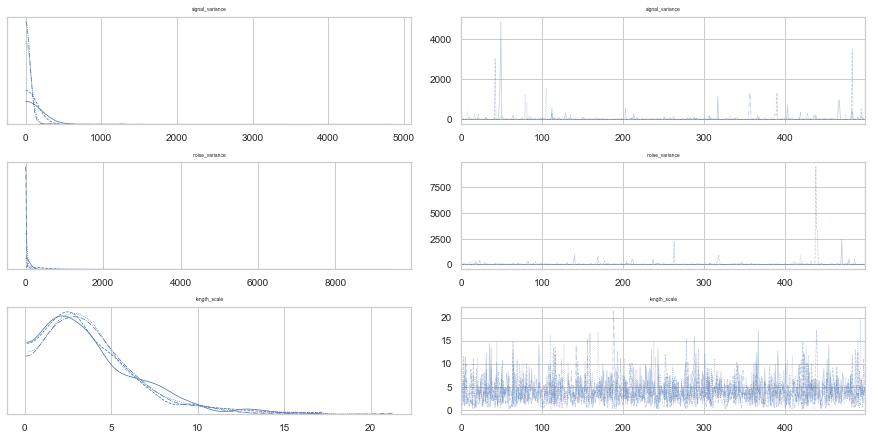

```python
pm.traceplot(posterior, varnames=["signal_variance", "noise_variance", "length_scale"]);
```

## Step 5: Critize the model

```python
pm.summary(posterior, varnames=["signal_variance", "noise_variance", "length_scale"])
```

|  | mean | sd | hpd_3% | hpd_97% | mcse_mean | mcse_sd | ess_mean | ess_sd | ess_bulk | ess_tail | r_hat |
| --- | --- | --- | --- | --- | --- | --- | --- | --- | --- | --- | --- |
| signal_variance | 27.685 | 178.687 | 0.002 | 52.693 | 4.920 | 3.480 | 1319.0 | 1319.0 | 2448.0 | 1081.0 | 1.0 |
| noise_variance | 27.975 | 253.932 | 0.012 | 53.814 | 8.322 | 5.886 | 931.0 | 931.0 | 2457.0 | 1216.0 | 1.0 |
| length_scale | 3.958 | 2.803 | 0.074 | 8.931 | 0.050 | 0.045 | 3146.0 | 1923.0 | 2973.0 | 1277.0 | 1.0 |

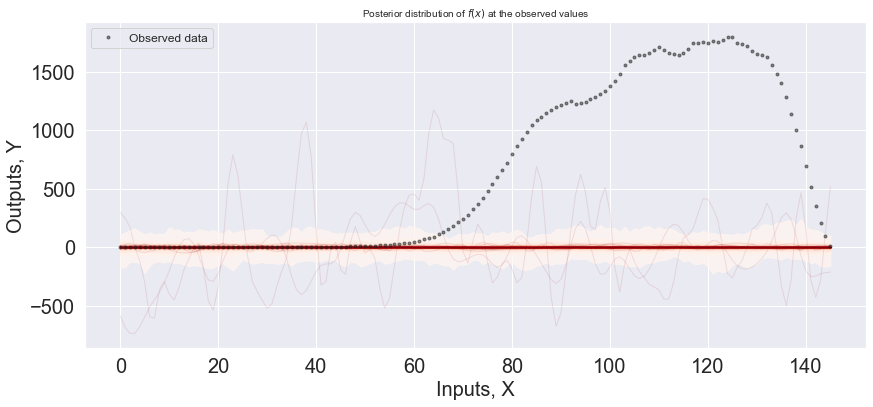

```python
fig2
```

[figure not shown]

```python
fig
```